# Forest Fire Area Classification

For this project, we will try to predict the scale of forest fires in Portugal to mitigate burn impact.

The data was sourced from University of California, Irvine Machine Learning Repository. https://archive.ics.uci.edu/ml/datasets/Forest+Fires

```python
from imblearn.over_sampling import SMOTE
import matplotlib.pyplot as plt
import numpy as np
import pandas as pd
import plotly.figure_factory as ff
from plotly.offline import iplot, init_notebook_mode
from rfpimp import *
import seaborn as sns
from sklearn.model_selection import train_test_split
from sklearn.linear_model import LogisticRegression
from sklearn.neighbors import KNeighborsClassifier
from sklearn.naive_bayes import GaussianNB
from sklearn.svm import SVC
from sklearn.ensemble import RandomForestClassifier
from sklearn.metrics import recall_score
from sklearn.metrics import precision_score
from sklearn.metrics import f1_score
from sklearn.metrics import fbeta_score
from sklearn.metrics import confusion_matrix
from sklearn.metrics import precision_recall_fscore_support
from sklearn.pipeline import Pipeline
from sklearn.preprocessing import StandardScaler
from sklearn.model_selection import RandomizedSearchCV
from sklearn.model_selection import cross_validate
import plotly.figure_factory as ff
from plotly.offline import iplot, init_notebook_mode
```

## Load and inspect the data

The data has 13 attributes and 517 observations. It is also clean, without any null values.

```python
df_fires = pd.read_csv("forestfires.csv")
```

```python
df_fires.shape
```

```
(517, 13)
```

```python
df_fires.head()
```

|  | X | Y | month | day | FFMC | DMC | DC | ISI | temp | RH | wind | rain | area |
| --- | --- | --- | --- | --- | --- | --- | --- | --- | --- | --- | --- | --- | --- |
| 0 | 7 | 5 | mar | fri | 86.2 | 26.2 | 94.3 | 5.1 | 8.2 | 51 | 6.7 | 0.0 | 0.0 |
| 1 | 7 | 4 | oct | tue | 90.6 | 35.4 | 669.1 | 6.7 | 18.0 | 33 | 0.9 | 0.0 | 0.0 |
| 2 | 7 | 4 | oct | sat | 90.6 | 43.7 | 686.9 | 6.7 | 14.6 | 33 | 1.3 | 0.0 | 0.0 |
| 3 | 8 | 6 | mar | fri | 91.7 | 33.3 | 77.5 | 9.0 | 8.3 | 97 | 4.0 | 0.2 | 0.0 |
| 4 | 8 | 6 | mar | sun | 89.3 | 51.3 | 102.2 | 9.6 | 11.4 | 99 | 1.8 | 0.0 | 0.0 |

```python
print(f"{'Feature':<15} Null Values" + '\n')
for col_name in df_fires:
    print(f'{col_name:<15} {df_fires[col_name].isnull().sum()}')
```

```
Feature         Null Values

X               0
Y               0
month           0
day             0
FFMC            0
DMC             0
DC              0
ISI             0
temp            0
RH              0
wind            0
rain            0
area            0
```

## Feature engineering

```python
# turning date data into numerical
def process_date(df):
    df['month'] = df['month'].map({'mar':3, 'oct':10, 'aug':8, 'sep':9, 'apr':4, 'jun':6, 'jul':7, 'feb':2, 'jan':1,
       'dec':12, 'may':5, 'nov':11})
    df['day'] = df['day'].map({'fri': 5, 'tue': 2, 'sat': 6, 'sun': 7, 'mon': 1, 'wed': 3, 'thu':4})
    return df
```

```python
# to make this problem a classification, we bin the data
def bins(df):
    df.loc[df.area >= 100, 'label'] = 2
    df.loc[(df.area >= 20) & (df.area < 100), 'label'] = 1
    df.loc[(df.area >= 0) & (df.area < 20), 'label'] = 0
    return df
```

```python
# wrapper
def process(df):
    df = process_date(df)
    df = bins(df)
    return df
```

```python
df_fires_processed = process(df_fires)
```

```python
df_fires_processed.head()
```

|  | X | Y | month | day | FFMC | DMC | DC | ISI | temp | RH | wind | rain | area | label |
| --- | --- | --- | --- | --- | --- | --- | --- | --- | --- | --- | --- | --- | --- | --- |
| 0 | 7 | 5 | 3 | 5 | 86.2 | 26.2 | 94.3 | 5.1 | 8.2 | 51 | 6.7 | 0.0 | 0.0 | 0.0 |
| 1 | 7 | 4 | 10 | 2 | 90.6 | 35.4 | 669.1 | 6.7 | 18.0 | 33 | 0.9 | 0.0 | 0.0 | 0.0 |
| 2 | 7 | 4 | 10 | 6 | 90.6 | 43.7 | 686.9 | 6.7 | 14.6 | 33 | 1.3 | 0.0 | 0.0 | 0.0 |
| 3 | 8 | 6 | 3 | 5 | 91.7 | 33.3 | 77.5 | 9.0 | 8.3 | 97 | 4.0 | 0.2 | 0.0 | 0.0 |
| 4 | 8 | 6 | 3 | 7 | 89.3 | 51.3 | 102.2 | 9.6 | 11.4 | 99 | 1.8 | 0.0 | 0.0 | 0.0 |

```python
y = df_fires_processed.iloc[:,-1]
X = df_fires_processed.iloc[:,:-2]
```

## Preprocessing the imbalance

This dataset is a very imbalanced one. Most of the target values (area) are 0s, which according to the paper indicate fires smaller than 0.01 hectares.

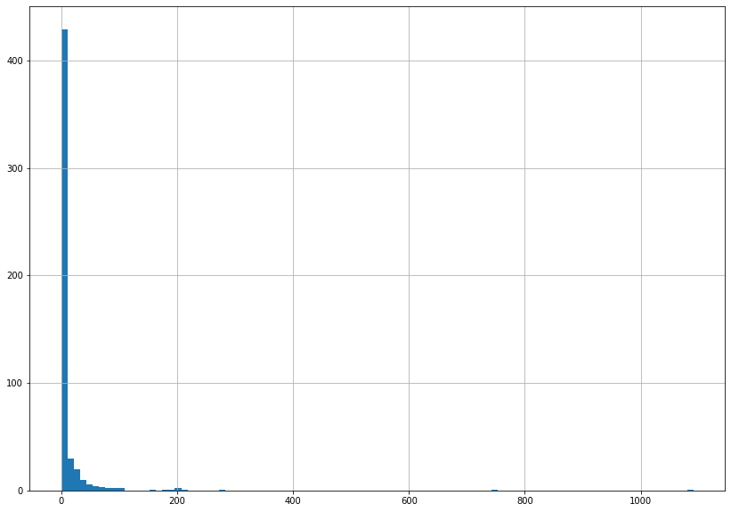

```python
df_fires_processed['area'].hist(bins = 100, figsize = (14,10))
plt.show()
```

We used SMOTE upsampling method to generate a more balanced training set for our models.

```python
# split and smote
X_train, X_test, y_train, y_test = train_test_split(X, y, test_size=0.2, random_state=42)
X_smote, y_smote = SMOTE()\
                    .fit_sample(X_train, y_train)
```

## Model selection

### Fit models

We fit 5 different models to compare their performances. To make this process nice and neat, we made a pipeline that fits models and implements standardscaling where appropriate.

```python
# make a pipeline that fits 5 models
def make_pipelines():
    """Create a pipeline for each of the following algorithms:
    1. Logistic Regression
    2. k-nearest neighbors (KNN)
    3. Naive Bayes (Guassian)
    4. Support Vector Machines (SVM)
    5. Random Forest™

    If appropriate, apply StandardScaler before the algorithm.
    Use default hyperparameters.
    If an algorithm takes random_state then random_state=42

    Return a list of all the pipelines.
    """
    pipe_lr = Pipeline([('scl', StandardScaler()), ('clf', LogisticRegression(random_state=42))])
    pipe_knn = Pipeline([('scl', StandardScaler()), ('clf', KNeighborsClassifier())])
    pipe_bayes = Pipeline([('clf', GaussianNB())])
    pipe_svm = Pipeline([('scl', StandardScaler()),('clf', SVC(random_state=42))])
    pipe_rf = Pipeline([('clf', RandomForestClassifier(n_estimators=100, random_state=42))])

    pipelines = [pipe_lr, pipe_knn, pipe_bayes, pipe_svm, pipe_rf]

    return pipelines
```

```python
# fit models
pipelines = make_pipelines()
for pipe in pipelines:
    pipe.fit(X_smote, y_smote)
```

### Compare model performances

We want a north star metric to guide the model selection process that would account for the imbalanced classes in our data. Accuracy is not appropriate because it rewards predicting the most frequent class. In the context of our research question, we don't favor one of Precision or Recall over the other, so we will weight them equally and use F1 score (https://scikit-learn.org/stable/modules/generated/sklearn.metrics.f1_score.html).

However, since our task is classifying into multiple categories (and not simple binary classification), we need to a way to weight the F1 scores for each class to produce a single metric.

#### Baseline model

For our baseline model, we chose to predict all of the fires to be categorized as small because of the imbalanced dataset. As many model can produce great scores from predicting only the majority, we wanted to compare different metrics to determine which best distinguishes the better performing models.

#### Our set of models

```python
def sort_models(pipelines, X_data, y_data, metric=f1_score, average='weighted', matrix=False):
    scores_sorted = {}
    for pipe in pipelines:
        y_pred = pipe.predict(X_data)
        algname = str(type(pipe.named_steps['clf'])).split('.')[-1].replace("'>","")
        if matrix:
            print(algname)
            print(confusion_matrix(y_data, y_pred))
        scores_sorted[algname] = metric(y_data, y_pred, average=average)
    scores_sorted = dict(sorted(scores_sorted.items(), key=lambda x: x[1], reverse=True))

    return scores_sorted
```

```python
# display F1 score and confusion matrices
score = sort_models(pipelines, X_test, y_test, metric=f1_score, matrix=True)
print('\nModel metrics in descending order:')
print(score)
```

```
LogisticRegression
[[40 23 28]
 [ 3  4  4]
 [ 1  0  1]]
KNeighborsClassifier
[[47 33 11]
 [ 6  5  0]
 [ 1  1  0]]
GaussianNB
[[11 48 32]
 [ 2  6  3]
 [ 0  0  2]]
SVC
[[68 19  4]
 [ 7  4  0]
 [ 2  0  0]]
RandomForestClassifier
[[86  4  1]
 [10  1  0]
 [ 1  0  1]]

Model metrics in descending order:
{'RandomForestClassifier': 0.8233684533551554, 'SVC': 0.7332202111613877, 'KNeighborsClassifier': 0.588395225464191, 'LogisticRegression': 0.5418846260951524, 'GaussianNB': 0.20659516765285996}
```

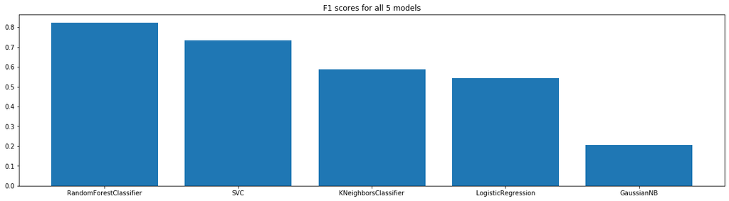

```python
plt.bar(range(len(score)), list(score.values()), align='center')
plt.xticks(range(len(score)), list(score.keys()))
plt.rcParams["figure.figsize"] = (20,5)
plt.title("F1 scores for all 5 models")
plt.show()
```

We will select a more appropriate metric and proceed with further analysis.

### Hyperparameter tuning with Random search Cross Validation

We decided to pick random forest as our first experiment. We carried out hyperparameter tuning, followed by feature selection according to permutation importances, to decide on our final features and model.

#### Random search CV for random forest

```python
n_estimators = [5, 10, 50]
criterion = ['gini', 'entropy']
min_samples_split = [2, 4, 6]


hyperparameters = dict(n_estimators=n_estimators,
                       criterion=criterion,
                       min_samples_split=min_samples_split)

clf_rand = RandomizedSearchCV(RandomForestClassifier(),
                              hyperparameters,
                              cv=5,
                              n_iter=13,
                              verbose=1)
clf_rand.fit(X_smote, y_smote)
```

```
Fitting 5 folds for each of 13 candidates, totalling 65 fits
```

[output not shown]

```
RandomizedSearchCV(cv=5, error_score='raise-deprecating',
                   estimator=RandomForestClassifier(bootstrap=True,
                                                    class_weight=None,
                                                    criterion='gini',
                                                    max_depth=None,
                                                    max_features='auto',
                                                    max_leaf_nodes=None,
                                                    min_impurity_decrease=0.0,
                                                    min_impurity_split=None,
                                                    min_samples_leaf=1,
                                                    min_samples_split=2,
                                                    min_weight_fraction_leaf=0.0,
                                                    n_estimators='warn',
                                                    n_jobs=None,
                                                    oob_score=False,
                                                    random_state=None,
                                                    verbose=0,
                                                    warm_start=False),
                   iid='warn', n_iter=13, n_jobs=None,
                   param_distributions={'criterion': ['gini', 'entropy'],
                                        'min_samples_split': [2, 4, 6],
                                        'n_estimators': [5, 10, 50]},
                   pre_dispatch='2*n_jobs', random_state=None, refit=True,
                   return_train_score=False, scoring=None, verbose=1)
```

```python
# fit the tuned model
rf = clf_rand.estimator
rf.fit(X_smote, y_smote)
```

```
RandomForestClassifier(bootstrap=True, class_weight=None, criterion='gini',
                       max_depth=None, max_features='auto', max_leaf_nodes=None,
                       min_impurity_decrease=0.0, min_impurity_split=None,
                       min_samples_leaf=1, min_samples_split=2,
                       min_weight_fraction_leaf=0.0, n_estimators=10,
                       n_jobs=None, oob_score=False, random_state=None,
                       verbose=0, warm_start=False)
```

### Feature importances

To see the feature importances, we group the X and Y variables, because they share importances as geographical attributes.

```python
feature_list = [['X', 'Y'], 'month', 'day', 'FFMC', 'DMC', 'DC', 'ISI', 'temp', 'RH', 'wind', 'rain']
```

```
         Importance
Feature
ISI        0.057692
X\nY       0.048077
month      0.048077
DMC        0.038462
temp       0.038462
wind       0.038462
DC         0.019231
RH         0.019231
day        0.009615
FFMC       0.000000
rain       0.000000
<rfpimp.PimpViz object at 0x12a171bd0>
```

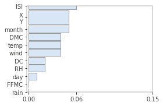

```python
I = importances(rf, X_test, y_test, features=feature_list)
print(I)
print(plot_importances(I))
```

We repeated the feature importance process, and the results were relatively stable. We selected FFMC and rain to be dropped out of our features.

```python
# dropping columns
dfc = df_fires_processed.drop(columns=['rain', 'FFMC'])
y = dfc.iloc[:,-1]
X = dfc.iloc[:,:-2]

# split, smote and train
X_train_rf, X_test_rf, y_train_rf, y_test_rf = train_test_split(X, y, test_size=0.2, random_state=38)
X_smote_rf, y_smote_rf = SMOTE(random_state=49)\
                    .fit_sample(X_train_rf, y_train_rf)
rf.fit(X_smote_rf, y_smote_rf)

# predict and look at the confusion matrix
pred = rf.predict(X_test_rf)
print(confusion_matrix(y_test_rf, pred))
```

[output not shown]

## Cross validation

```python
# use cv on training sets to see if our forest is overfit
cv_results = cross_validate(rf, X_smote_rf, y_smote_rf, scoring='f1_macro', cv=5)
cv_results
```

```
{'fit_time': array([0.02525306, 0.02818108, 0.02266407, 0.02368307, 0.02269483]),
 'score_time': array([0.00249887, 0.00327587, 0.00206304, 0.00210977, 0.001966  ]),
 'test_score': array([0.86566241, 0.92729512, 0.9451405 , 0.91866214, 0.92256949])}
```

The test scores for 5 folds look good!

## Compare with baseline model

The classification problem is a difficult one, particularly because the data is imbalanced. We select a naive prediction method that predicts all fires to be small, and compare our model with it.

```python
our_score = fbeta_score(y_test_rf, pred, beta=0.01, average='weighted')
naive_score = fbeta_score(y_test_rf, np.array([0]*len(pred)), beta=0.01, average='weighted')
print(f'Using weighted f1 score,\nour model achieves: {our_score},\nthe naive model achieves: {naive_score}')
```

```
Using weighted f1 score,
our model achieves: 0.7738067886840899,
the naive model achieves: 0.7159873454494678
```

```python
our_score = f1_score(y_test_rf, pred, average='macro')
naive_score = f1_score(y_test_rf, np.array([0]*len(pred)), average='macro')
print(f'Using F1-macro score,\nour model achieves: {our_score},\nthe naive model achieves: {naive_score}')
```

```
Using F1-macro score,
our model achieves: 0.47013785466070956,
the naive model achieves: 0.3055555555555555
```

## Conclusion

### A visualization of the confusion matrix on test set

```python
init_notebook_mode()
z = confusion_matrix(y_test_rf, pred)
x = ['Predicted Small', 'Predicted Medium', 'Predicted Large']
y = ['Actual Small', 'Actual Medium', 'Actual Large']
fig = ff.create_annotated_heatmap(z, x=x, y=y, colorscale='Blues')
fig.show()
```

[interactive chart not shown]